# Malaria worldwide

Anna Reynolds

2018-11-18

## Overview

This weeks #TidyTuesday is on Malaria data from [Our World in Data](https://ourworldindata.org/malaria). I have chosen to concentrate on the data set containing Malaria deaths by age across the world and time. It contains data from 1990 to 2016 for countries worldwide.

## Load data

```r
library(tidyverse)
library(here)
library(ggthemr)
library(knitr)
library(scales)
library(DataExplorer)
malaria <- read_csv(here("malaria_deaths_age.csv"))
kable(head(malaria))
```

| obs_number | country | code | year | age_group | deaths |
| --- | --- | --- | --- | --- | --- |
| 1 | Afghanistan | AFG | 1990 | Under 5 | 184.6064 |
| 2 | Afghanistan | AFG | 1991 | Under 5 | 191.6582 |
| 3 | Afghanistan | AFG | 1992 | Under 5 | 197.1402 |
| 4 | Afghanistan | AFG | 1993 | Under 5 | 207.3578 |
| 5 | Afghanistan | AFG | 1994 | Under 5 | 226.2094 |
| 6 | Afghanistan | AFG | 1995 | Under 5 | 236.3280 |

```r
#Set theme
ggthemr(palette = "light", set_theme = TRUE)
kable(introduce(malaria))
```

| rows | columns | discrete_columns | continuous_columns | all_missing_columns | total_missing_values | complete_rows | total_observations | memory_usage |
| --- | --- | --- | --- | --- | --- | --- | --- | --- |
| 30780 | 6 | 3 | 3 | 0 | 4320 | 26460 | 184680 | 1258744 |

## Analysis/visualization

### Deaths by age for the world - children under 5 impacted the most by malaria

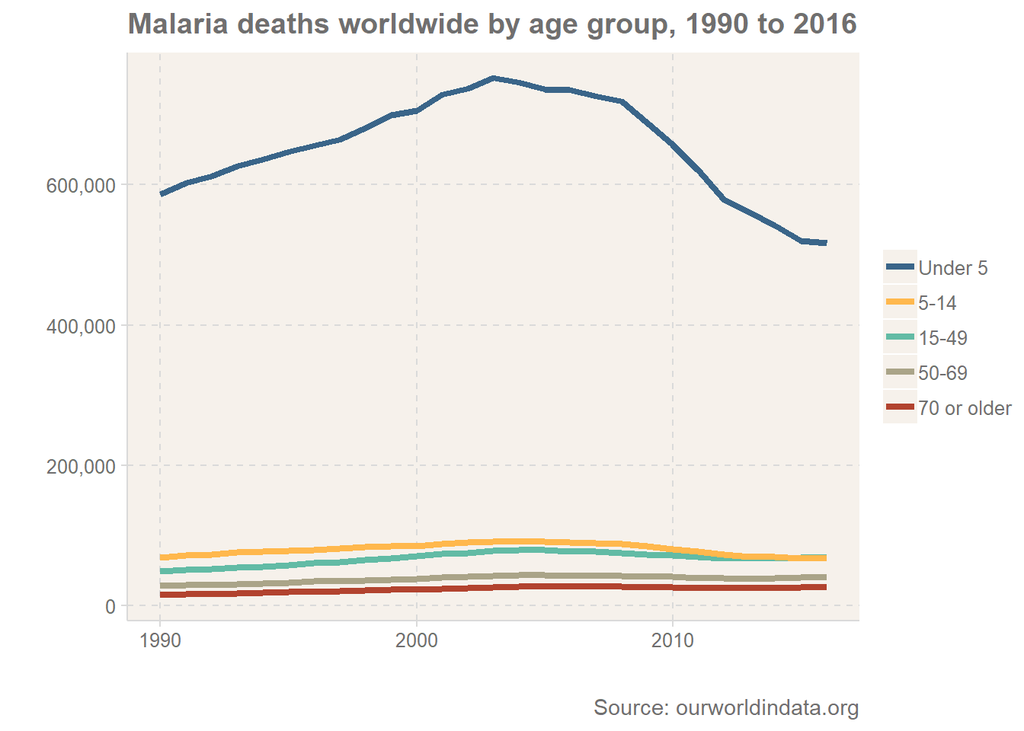

```r
world <- malaria %>% filter(country == "World")
line <- ggplot(world, aes(year, deaths, group = age_group, color = age_group)) + geom_line(size = 1.5) +
  scale_y_continuous(labels = comma_format()) + labs(
  x = " ",
  y = " ",
  title = "Malaria deaths worldwide by age group, 1990 to 2016",
  caption = "Source: ourworldindata.org"
  ) + theme(legend.title = element_blank()) +
  scale_color_discrete(breaks=c("Under 5", "5-14", "15-49", "50-69", "70 or older"))
line
```

Interactive line chart

```r
library(plotly)
ggplotly(line)
```

[interactive chart not shown]

## Results

- Children aged under 5 have a much higher number of deaths than the other age groups
- Deaths in children under 5 peaked in 2003 with around 750,000 but declined to around 510,000 in 2016.

## Package citations

Boxuan Cui (2018). DataExplorer: Data Explorer. R package version 0.7.0. https://CRAN.R-project.org/package=DataExplorer

Ciaran Tobin (NA). ggthemr: Themes for ggplot2. R package version 1.1.0.

Hadley Wickham (2017). tidyverse: Easily Install and Load the ‘Tidyverse’. R package version 1.2.1. https://CRAN.R-project.org/package=tidyverse

Hadley Wickham (2018). stringr: Simple, Consistent Wrappers for Common String Operations. R package version 1.3.0. https://CRAN.R-project.org/package=stringr

Yihui Xie (2018). knitr: A General-Purpose Package for Dynamic Report Generation in R. R package version 1.20.

Carson Sievert, Chris Parmer, Toby Hocking, Scott Chamberlain, Karthik Ram, Marianne Corvellec and Pedro Despouy (2017). plotly: Create Interactive Web Graphics via ‘plotly.js’. R package version 4.7.1. https://CRAN.R-project.org/package=plotly